# Diagnostic Report for OM #: 274

North Atlantic Swordfish MSE

Adrian Hordyk adrian@bluematterscience.com

April 22, 2020

# 1 Operating Model Scenario

Table 1. The uncertainty grid is a full factorial design with the following 7 factors, resulting in 288 OMs. The parameters used in this OM are indicated with bold text in blue boxes.

| M | sigmaR | h | CPUE CV | Len. Comp. Eff. Samp. Size | Q increase | Env. Covariate |
| --- | --- | --- | --- | --- | --- | --- |
| 0.1 | 0.2 | 0.6 | 0.3 | 2 | 1 | FALSE |
| 0.2 | 0.6 | 0.75 | 0.6 | 20 | 1.01 | TRUE |
| 0.3 |  | 0.9 |  |  |  |  |

# 2 Fleet Information

Table 2. The model was fitted to the following 16 indices.

| index | Name | Code |
| --- | --- | --- |
| 1 | Spain | SPN_1 |
| 2 | US | US_2 |
| 3 | Canada - Early | CAN_ERLY_5 |
| 4 | Canada - Late | CAN_LATE_4 |
| 5 | Japan - Early | JPN_ERLY_5 |
| 6 | Japan - Mid | JPN_MID_6 |
| 7 | Japan - Late | JPN_LATE_7 |
| 8 | Portugal | PORT_8 |
| 9 | Chinese-Taipai | CHIN-TAI_9 |
| 10 | Morocco | MOR_10 |
| 11 | Other | OTH_11 |
| 12 | Age-1 Survey | Age-1 |
| 13 | Age-2 Survey | Age-2 |
| 14 | Age-3 Survey | Age-3 |
| 15 | Age-4 Survey | Age-4 |
| 16 | Age-5+ Survey | Age-5+ |

# 3 Data Summary

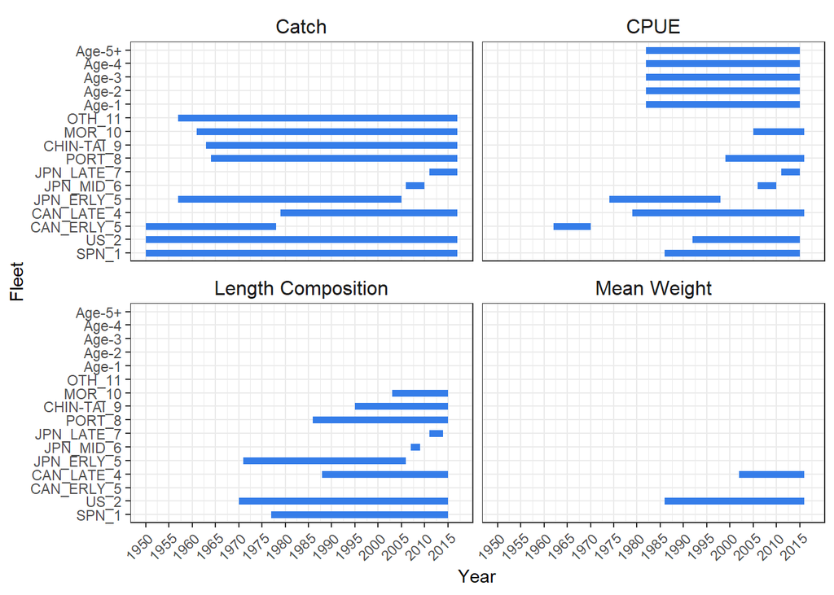

Figure 1. The time periods for the data used in the model.

# 4 Objective Function Values

## 4.1 Overall

Table 3. The total and component overall likelihood values.

| TOTAL | 622.9800000 |
| --- | --- |
| Catch | 0.0000000 |
| Equil_catch | 0.0000000 |
| Survey | -111.9100000 |
| Mean_body_wt | 130.1630000 |
| Length_comp | 595.6170000 |
| Recruitment | 9.1050300 |
| Forecast_Recruitment | 0.0000000 |
| Parm_priors | 0.0000217 |
| Parm_softbounds | 0.0061450 |
| Parm_devs | 0.0000000 |
| Crash_Pen | 0.0000000 |

## 4.2 By Fleet

Table 4. The total and component likelihood values for each fleet.

| Label | Catch_like | Surv_like | mnwt_like | Length_like |
| --- | --- | --- | --- | --- |
| ALL | 2.26328e-09 | -1.11910e+02 | 1.30163e+02 | 5.95617e+02 |
| SPN_1 | 5.03837e-10 | 1.41645e+03 | 0.00000e+00 | 4.55669e+01 |
| US_2 | 3.71520e-10 | -1.06290e+01 | 8.05054e+01 | 5.85079e+01 |
| CAN_ERLY_5 | 8.45148e-15 | -2.54217e+00 | 0.00000e+00 | 0.00000e+00 |
| CAN_LATE_4 | 4.25525e-11 | -1.47671e+01 | 4.96571e+01 | 1.20727e+02 |
| JPN_ERLY_5 | 2.81915e-10 | -3.20666e+00 | 0.00000e+00 | 1.02179e+02 |
| JPN_MID_6 | 1.77958e-12 | -4.65304e-01 | 0.00000e+00 | 1.10254e+01 |
| JPN_LATE_7 | 2.80271e-11 | -1.19413e+00 | 0.00000e+00 | 1.14486e+01 |
| PORT_8 | 5.03776e-10 | -7.33337e+00 | 0.00000e+00 | 6.45463e+01 |
| CHIN-TAI_9 | 5.18963e-11 | 0.00000e+00 | 0.00000e+00 | 1.52580e+02 |
| MOR_10 | 4.26071e-10 | -5.34034e+00 | 0.00000e+00 | 2.90360e+01 |
| OTH_11 | 5.18981e-11 | 0.00000e+00 | 0.00000e+00 | 0.00000e+00 |
| Age-1 | 0.0000 | -13.8146 | 0.0000 | 0.0000 |
| Age-2 | 0.000 | -14.486 | 0.000 | 0.000 |
| Age-3 | 0.0000 | -12.3558 | 0.0000 | 0.0000 |
| Age-4 | 0.0000 | -11.2873 | 0.0000 | 0.0000 |
| Age-5+ | 0.0000 | -14.4885 | 0.0000 | 0.0000 |

# 5 Model Fits

## 5.1 Fits to CPUE Indices

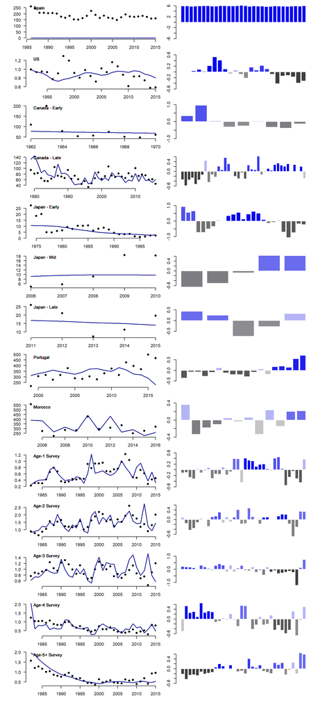

Figure 2. Operating model fits to the indices. Each row corresponds with an index. The left-hand panels show the observed (black dots) and model predicted (blue line) indices. The right-hand panels show the log devitations (the observation model is log-normal). Runs of positive residuals are coloured blue, with darker colours indicating longer runs. Run in negative residuals are colored in grey.

## 5.2 Statistical Properties

Table 5. The statistical properties of the model fits to the 14 indices.

| index | Fleet | Standard Deviation | Correlation | Auto-Correlation | Root Mean Squared Error | Mean Runs |
| --- | --- | --- | --- | --- | --- | --- |
| 1 | Spain | 0.09 | 0.8 | 0.37 | 7 | 30 |
| 2 | US | 0.23 | -0.06 | 0.61 | 1.08 | 5.08 |
| 3 | Canada - Early | 0.43 | 0.68 | 0.4 | 0.92 | 2.56 |
| 4 | Canada - Late | 0.3 | 0.36 | 0.35 | 1.43 | 6.37 |
| 5 | Japan - Early | 0.54 | 0.68 | 0.63 | 0.78 | 4.84 |
| 6 | Japan - Mid | 0.61 | 0.6 | 0.48 | 0.91 | 2.6 |
| 7 | Japan - Late | 0.49 | 0.46 | 0.04 | 0.87 | 1.8 |
| 8 | Portugal | 0.28 | -0.52 | 0.5 | 1.29 | 4.33 |
| 10 | Morocco | 0.23 | 0.53 | -0.3 | 0.85 | 1.67 |
| 12 | Age-1 Survey | 0.28 | 0.7 | 0.22 | 0.72 | 3.71 |

[output cut: 4 more lines]

# 6 Spawning Biomass

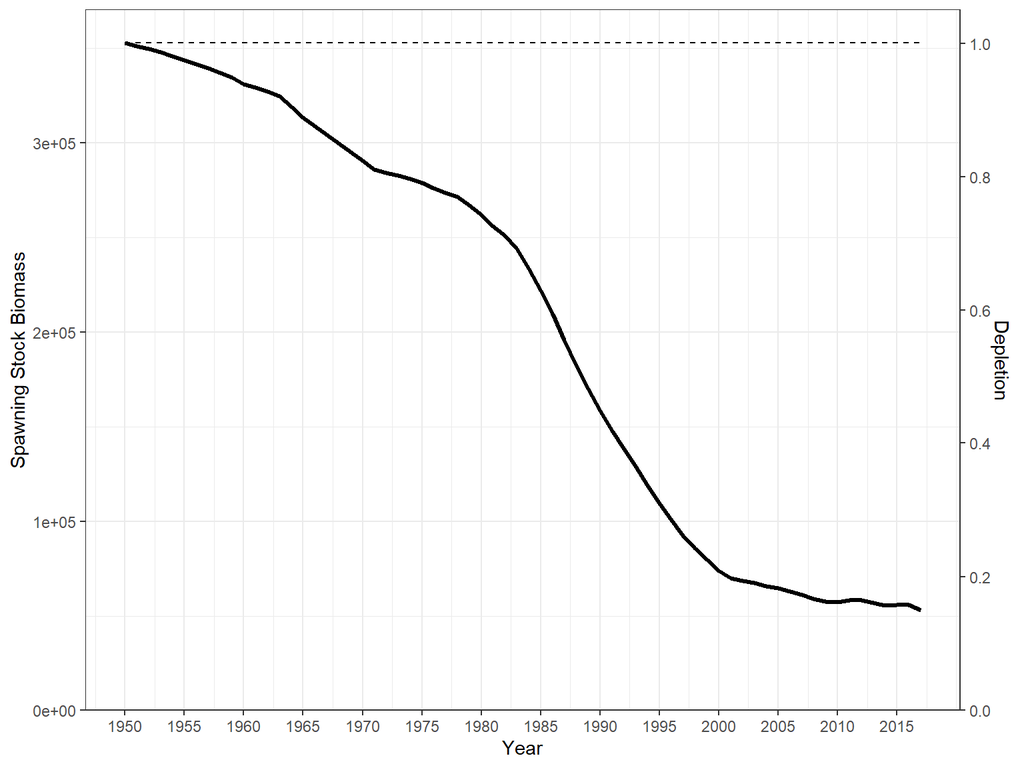

Figure 3. Plot of the predicted historical spawning stock biomass for OM: 274.

# 7 Recruitment

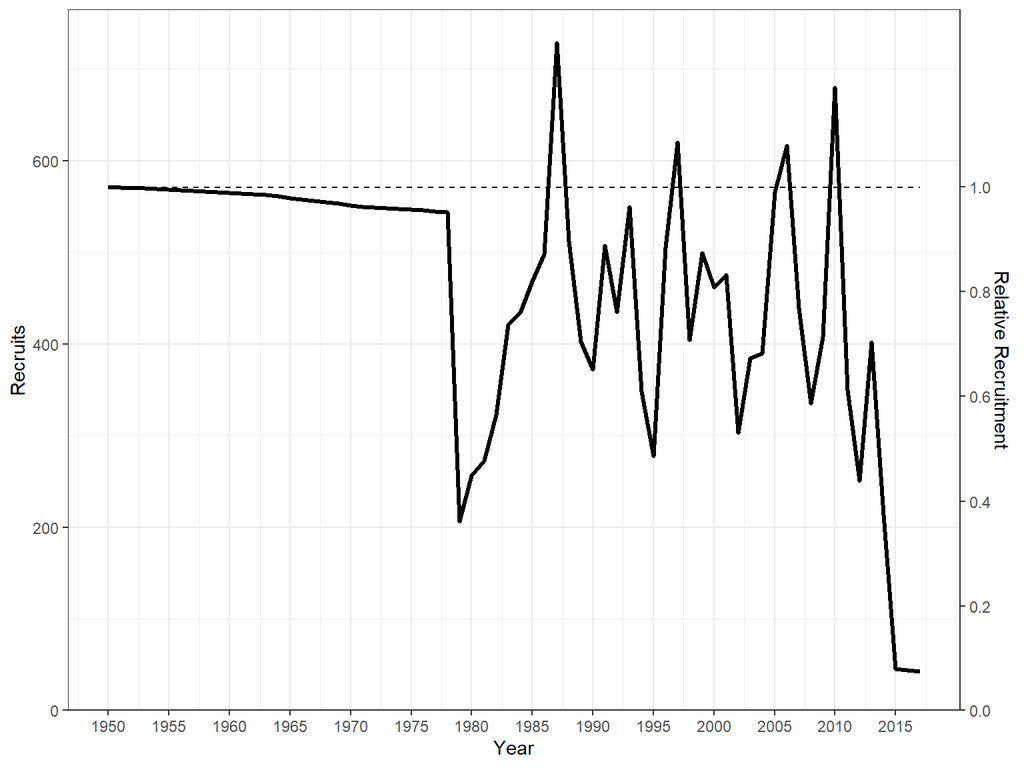

Figure 4. Plot of the predicted historical recruitment for OM: 274.

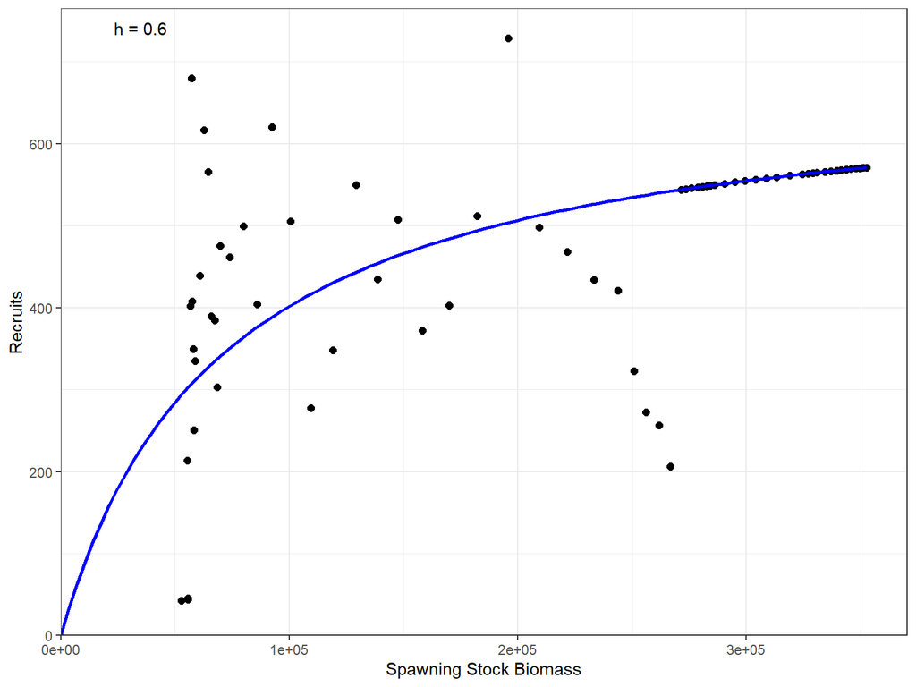

Figure 5. The expected stock-recruitment relationship (blue line) and predicted historical recruitment (black dots).

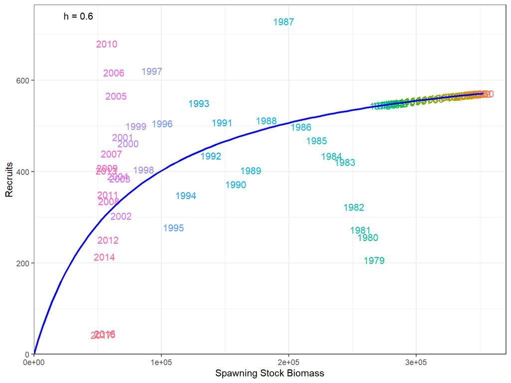

Figure 6. The expected stock-recruitment relationship (blue line) and predicted historical recruitment with years shown as coloured labels.

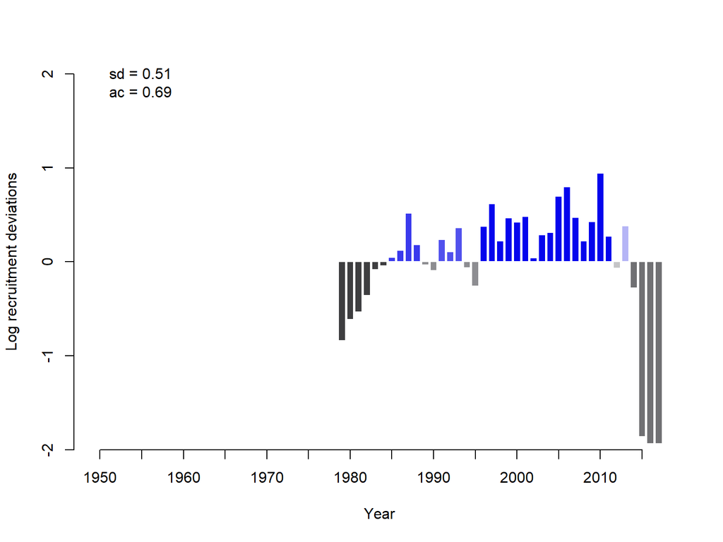

Figure 7. Recruitment deviations (log). Blue bars represent positive deviations where the estimated recruitment is higher than the mean value predicted from the stock-recruitment curve. Grey bars represent negative deviations. ‘sd’. and ‘ac’. refer to the Standard Deviation and lag-1 autocorrelation in recruitment deviations.

# 8 Reference Points

| MSY | SB<sub>MSY</sub> | F<sub>MSY</sub> | F/F<sub>MSY</sub> | SB/SB<sub>MSY</sub> | SB<sub>MSY</sub>/SB<sub>0</sub> | Depletion |
| --- | --- | --- | --- | --- | --- | --- |
| 8837.25 | 119139 | 0.04 | 3.08 | 0.44 | 0.34 | 0.15 |

# 9 Kobe Plot

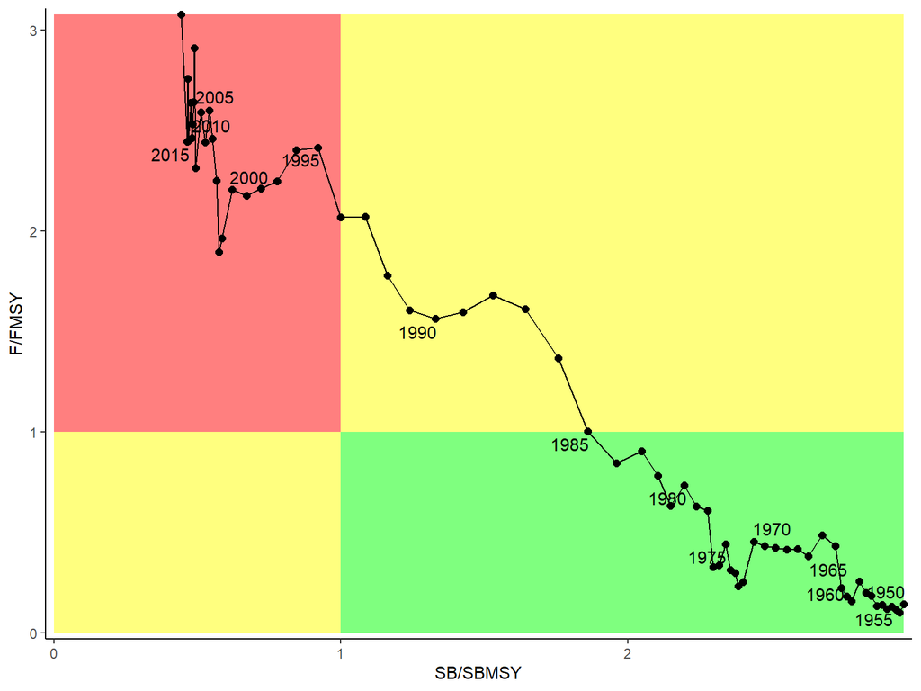

Figure 8. Kobe plot for OM: 274.

# 10 Selectivity

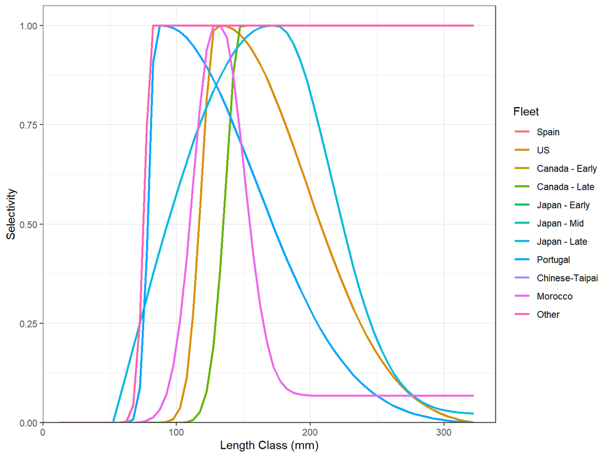

Figure 9. The estimated selectivity-at-length for the 11 fleets.

# 11 Fits to Catch Data

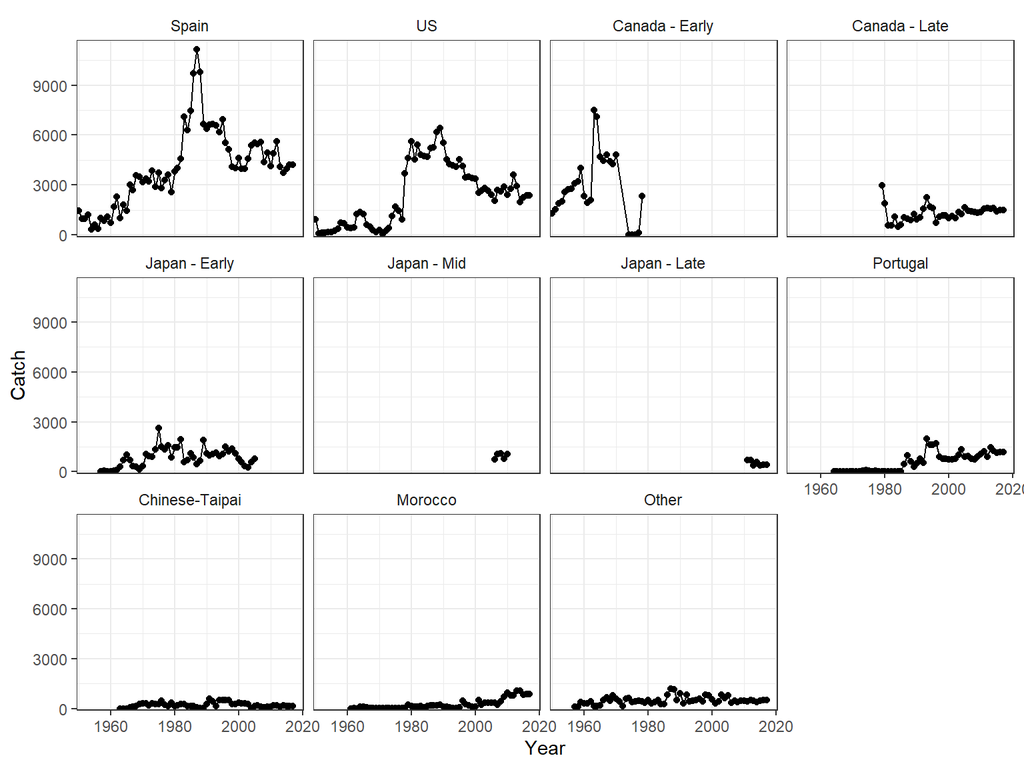

Figure 10. Fits to the catch data for the 11 fleets. All panels are shown with the same scale y-axis to indicate the magnitude of catches between fleets.

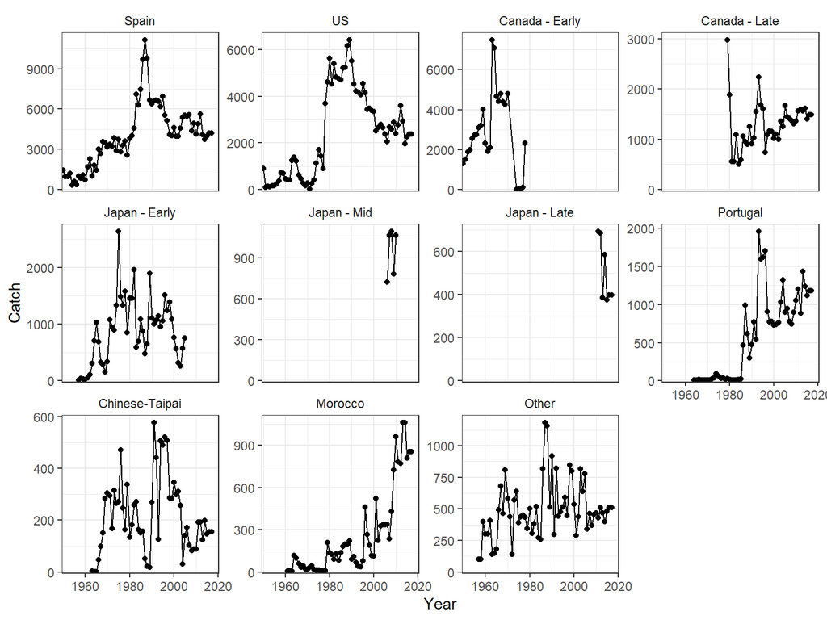

Figure 11. Fits to the catch data for the11 fleets with each y-axis is scaled separately.

# 12 Fits to Length Composition

## 12.1 Residual Plots

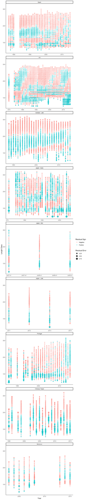

Figure 12. Length composition residuals showing residuals over time for each fleet. Blue circles are positive residuals (observed proportion is higher than expected), red circles are negative residuals. The area of the circle is proportional to the residual error where residual = (observed)^0.5 * (log(observed)-log(predicted)).

## 12.2 Fits to Aggregated Length Composition

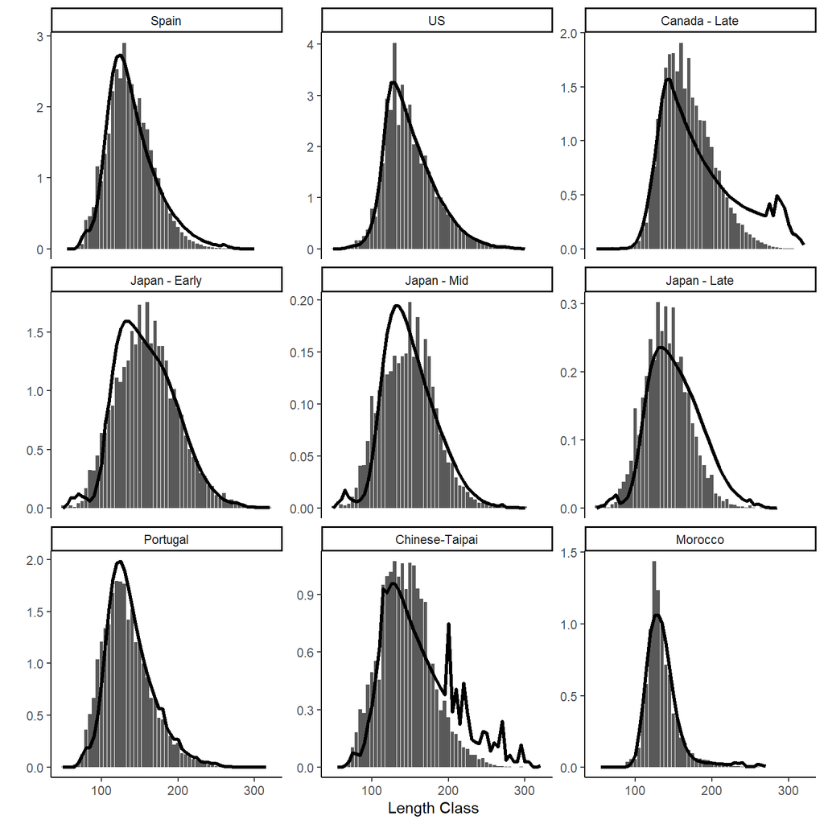